```python
#Connecting colab with google drive where dataset is
from google.colab import drive
drive.mount('/content/drive')
```

```python
cd /content/drive/MyDrive/CancerData
```

```
/content/drive/MyDrive/CancerData
```

# *DS 220 Project 2: An Introduction to U.S. Cancer Regression*

### *Data Analysis with Python Pandas - Joshua Santiago*

#### Team Members: Zack Ranajn, Patrick Erickson

> Professor Mathias Fonkman

## *Part 1: Introduction of the Dataset*

In this Jupyter Notebook, I conducted a data analysis of a Cancer-Regression Dataset using visualization tools to investigate the research questions that were formed as a group. The group, consisting of three members including myself, collectively came up with research questions through group brainstorming during team meetings. The data analysis of the research questions were split between all three members and then reviewed by the other two members to allow for both individual work and efficient group collaboration. However, much of the code within this Jupyter Notebook was either created, modified or altered by me to suit my derivations and insights for my own analysis.

The dataset analyzed was found at **[Kaggle](https://www.kaggle.com/datasets/varunraskar/cancer-regression?select=cancer_reg.csv)** which is an online platform open to the public containing published datasets for analysis, exploration, and sharing. This dataset contains two .csv files which were both used during the data analysis. The first file labeled "cancer_reg.csv" contains comprehensive data relating to Cancer within the U.S., with information collected from 2010 to 2016. The data in this file was recorded by reputable sources such as the National Cancer Institute and the National Library of Medicine. The second file labeled "avg-household-size.csv" contains aggregated data from the American Community Survey from 2015-2016. We can assume credibility for the dataset as the survey was conducted through census.gov.

The aim of the data analysis being conducted is to allow readers to understand the analysis of cancer data through the visual representation of the data by graphs and charts. The interpretation and explanation of the graphs and charts is intended to further help readers understand the analysis of data and answer any potential questions they may have from their initial interpretation of the data. The analysis of the data was a multi-step process which included importing necessary tools for statistical inference, loading the dataset, exploratory data analysis, data cleaning, statistical inference and visualizations, and the conclusion.

### *Section 1: Importing the Libraries*

To develop data visualization and code to support statistical analysis, the usage of libraries such as **pandas**, **numpy**, **matplotlib**, and **seaborn** were imported. The libraries **matplotlib** and **seaborn** were used for visualization compontents such as graphs and charts to display data to be more attractive and engaging to the reader. The libraries **pandas** and **numpy** were used to manipulate data and aid in our analysis.

```python
#Importing of Libraries
import pandas as pd
import numpy as np
import matplotlib.pyplot as plt
import seaborn as sns

#Set the aesthetic style of the plots
sns.set_style('whitegrid')
```

### *Section 2: Loading the Datasets*

To begin the analysis of data, I used pandas to load the two .csv files and convert them into a pandas dataframe. The "cancer_reg.csv" file is named "cancer_stats", and the "avg-household-size.csv" file is named "household_stats".

The "cancer_stats" dataframe includes **33** columns and **3047** rows of information. Important columns relevant to the statistical analysis of this dataset includes: (Note that these labels are the labels from the raw dataset which have not yet been renamed)

> 1. **avganncount**: Average number of cancer cases diagnosed annually
> 2. **avgdeathsperyear**: Average number of deaths due to cancer per year
> 3. **target_deathrate**: Target death rate due to cancer
> 4. **incidencerate**: Incident rate of cancer
> 5. **medincome**: Median income in the region
> 6. **popest2015**: Estimated population in 2015
> 7. **povertypercent**: Percentage of population below the poverty line
> 8. **studypercap**: Per capita number of cancer-related clinical trials conducted
> 9. **binnedinc**: Binned median income
> 10. **medianage**: Median age in the region
> 11. **medianagemale**: Median age of males in the region
> 12. **medianagefemale**: Median age of females in the region
> 13. **geography**: The geographical location, represented as the county or census area name followed by the state name
> 14. **pctemployed16_over**: Percentage of population age 16 and over that are employed
> 15. **pctunemployed16_over**: Percentage of the population age 16 and over that are unemployed
> 16. **pctprivatecoveragealone**: Percentage of the population covered by private health insurance alone
> 17. **pctempprivcoverage**: Percentage of the population covered by employee-provided health insurance
> 18. **pctpubliccoverage**: Percentage of population covered by public health insurance
> 19. **pctpubliccoveragealone**: Percentage of population covered by public health insurance only
> 20. **pctwhite**: Percentage of White population
> 21. **pctblack**: Percentage of Black population
> 22. **pctasian**: Percentage of Asian population
> 23. **pctotherrace**: Percentage of population belonging to other races
> 24. **pctmarried**: Percentage of population that is married
> 25. **pctmarriedhouseholds**: Percentage of married households
> 26. **birthrate**: Rate of birth within the region

The following columns are not included in the analysis as the research questions and interpretations do not concern them: **pctnohs18_24**, **pcths18_24**, **pctsomecol18_24**, **pctbachdeg18_24**, **pcths25_over**, and **pctbachdeg25_over**. These columns include data about population percentages of people ages 18-24 and 25+ not in/in high school and college, and without/with a bachelors degree.

The "household_stats" dataframe includes **4** columns and **3220** rows of information. The "geography" column holds the same values as the "geography" column in the "cancer_stats" dataframe. This will later be significant in merging together the two datasets. The other three columns which are relevant to the statistical analysis to this dataset includes:

> 1. **statefips**: The FIPS code representing the state
> 2. **countyfips**: The FIPS code representing the county or census area within the state
> 3. **avghouseholdsize**: The average household size in the region *Note*: A Federal Information Processing Standard (FIPS) code is a number that uniquely identifies a geograhpic area, and allows for the differentiation of counties within states that may share the same name.

```python
#Loading the datasets using pandas
cancer_stats = pd.read_csv('cancer_reg.csv')
household_stats = pd.read_csv('avg-household-size.csv')
```

```python
#Viewing cancer_stats dataframe
cancer_stats
```

|  | avganncount | avgdeathsperyear | target_deathrate | incidencerate | medincome | popest2015 | povertypercent | studypercap | binnedinc | medianage | ... | pctprivatecoveragealone | pctempprivcoverage | pctpubliccoverage | pctpubliccoveragealone | pctwhite | pctblack | pctasian | pctotherrace | pctmarriedhouseholds | birthrate |
| --- | --- | --- | --- | --- | --- | --- | --- | --- | --- | --- | --- | --- | --- | --- | --- | --- | --- | --- | --- | --- | --- |
| 0 | 1397.000000 | 469 | 164.9 | 489.800000 | 61898 | 260131 | 11.2 | 499.748204 | (61494.5, 125635] | 39.3 | ... | NaN | 41.6 | 32.9 | 14.0 | 81.780529 | 2.594728 | 4.821857 | 1.843479 | 52.856076 | 6.118831 |
| 1 | 173.000000 | 70 | 161.3 | 411.600000 | 48127 | 43269 | 18.6 | 23.111234 | (48021.6, 51046.4] | 33.0 | ... | 53.8 | 43.6 | 31.1 | 15.3 | 89.228509 | 0.969102 | 2.246233 | 3.741352 | 45.372500 | 4.333096 |
| 2 | 102.000000 | 50 | 174.7 | 349.700000 | 49348 | 21026 | 14.6 | 47.560164 | (48021.6, 51046.4] | 45.0 | ... | 43.5 | 34.9 | 42.1 | 21.1 | 90.922190 | 0.739673 | 0.465898 | 2.747358 | 54.444868 | 3.729488 |
| 3 | 427.000000 | 202 | 194.8 | 430.400000 | 44243 | 75882 | 17.1 | 342.637253 | (42724.4, 45201] | 42.8 | ... | 40.3 | 35.0 | 45.3 | 25.0 | 91.744686 | 0.782626 | 1.161359 | 1.362643 | 51.021514 | 4.603841 |
| 4 | 57.000000 | 26 | 144.4 | 350.100000 | 49955 | 10321 | 12.5 | 0.000000 | (48021.6, 51046.4] | 48.3 | ... | 43.9 | 35.1 | 44.0 | 22.7 | 94.104024 | 0.270192 | 0.665830 | 0.492135 | 54.027460 | 6.796657 |
| ... | ... | ... | ... | ... | ... | ... | ... | ... | ... | ... | ... | ... | ... | ... | ... | ... | ... | ... | ... | ... | ... |
| 3042 | 1962.667684 | 15 | 149.6 | 453.549422 | 46961 | 6343 | 12.4 | 0.000000 | (45201, 48021.6] | 44.2 | ... | 54.9 | 44.6 | 31.7 | 13.2 | 90.280811 | 3.837754 | 0.327613 | 1.700468 | 51.063830 | 7.773512 |
| 3043 | 1962.667684 | 43 | 150.1 | 453.549422 | 48609 | 37118 | 18.8 | 377.175494 | (48021.6, 51046.4] | 30.4 | ... | 53.3 | 48.6 | 28.8 | 17.7 | 75.706245 | 2.326771 | 4.044920 | 14.130288 | 52.007937 | 8.186470 |
| 3044 | 1962.667684 | 46 | 153.9 | 453.549422 | 51144 | 34536 | 15.0 | 1968.959926 | (51046.4, 54545.6] | 30.9 | ... | 52.6 | 47.8 | 26.6 | 16.8 | 87.961629 | 2.313188 | 1.316472 | 5.680705 | 55.153949 | 7.809192 |
| 3045 | 1962.667684 | 52 | 175.0 | 453.549422 | 50745 | 25609 | 13.3 | 0.000000 | (48021.6, 51046.4] | 39.0 | ... | 56.3 | 49.6 | 29.5 | 14.0 | 92.905681 | 1.176562 | 0.244632 | 2.131790 | 58.484232 | 7.582938 |
| 3046 | 1962.667684 | 48 | 213.6 | 453.549422 | 41193 | 37030 | 13.9 | 0.000000 | (40362.7, 42724.4] | 26.2 | ... | 60.3 | 22.9 | 25.1 | 12.6 | 70.098132 | 16.590100 | 3.177753 | 1.356457 | 56.040242 | 8.981723 |

3047 rows × 33 columns

```python
#Viewing household_stats dataframe
household_stats
```

|  | statefips | countyfips | avghouseholdsize | geography |
| --- | --- | --- | --- | --- |
| 0 | 2 | 13 | 2.43 | Aleutians East Borough, Alaska |
| 1 | 2 | 16 | 3.59 | Aleutians West Census Area, Alaska |
| 2 | 2 | 20 | 2.77 | Anchorage Municipality, Alaska |
| 3 | 2 | 50 | 3.86 | Bethel Census Area, Alaska |
| 4 | 2 | 60 | 2.50 | Bristol Bay Borough, Alaska |
| ... | ... | ... | ... | ... |
| 3215 | 56 | 37 | 2.64 | Sweetwater County, Wyoming |
| 3216 | 56 | 39 | 2.63 | Teton County, Wyoming |
| 3217 | 56 | 41 | 2.76 | Uinta County, Wyoming |
| 3218 | 56 | 43 | 2.34 | Washakie County, Wyoming |
| 3219 | 56 | 45 | 2.27 | Weston County, Wyoming |

3220 rows × 4 columns

## *Part 2: Exploratory Data Analysis*

Before begining the statistical analysis of data, it is important to first examine the data to gain a more extensive understanding of the datasets. I did this by first viewing the first 5 and last 5 rows of each dataframe. I also found the shape of both dataframes to find the number of rows and columns in each dataframe. Furthermore, I examined the data-types and non-null values of the columns in each dataframe.

```python
#Display first 5 rows of the cancer_stats dataframe
cancer_stats.head()
```

|  | avganncount | avgdeathsperyear | target_deathrate | incidencerate | medincome | popest2015 | povertypercent | studypercap | binnedinc | medianage | ... | pctprivatecoveragealone | pctempprivcoverage | pctpubliccoverage | pctpubliccoveragealone | pctwhite | pctblack | pctasian | pctotherrace | pctmarriedhouseholds | birthrate |
| --- | --- | --- | --- | --- | --- | --- | --- | --- | --- | --- | --- | --- | --- | --- | --- | --- | --- | --- | --- | --- | --- |
| 0 | 1397.0 | 469 | 164.9 | 489.8 | 61898 | 260131 | 11.2 | 499.748204 | (61494.5, 125635] | 39.3 | ... | NaN | 41.6 | 32.9 | 14.0 | 81.780529 | 2.594728 | 4.821857 | 1.843479 | 52.856076 | 6.118831 |
| 1 | 173.0 | 70 | 161.3 | 411.6 | 48127 | 43269 | 18.6 | 23.111234 | (48021.6, 51046.4] | 33.0 | ... | 53.8 | 43.6 | 31.1 | 15.3 | 89.228509 | 0.969102 | 2.246233 | 3.741352 | 45.372500 | 4.333096 |
| 2 | 102.0 | 50 | 174.7 | 349.7 | 49348 | 21026 | 14.6 | 47.560164 | (48021.6, 51046.4] | 45.0 | ... | 43.5 | 34.9 | 42.1 | 21.1 | 90.922190 | 0.739673 | 0.465898 | 2.747358 | 54.444868 | 3.729488 |
| 3 | 427.0 | 202 | 194.8 | 430.4 | 44243 | 75882 | 17.1 | 342.637253 | (42724.4, 45201] | 42.8 | ... | 40.3 | 35.0 | 45.3 | 25.0 | 91.744686 | 0.782626 | 1.161359 | 1.362643 | 51.021514 | 4.603841 |
| 4 | 57.0 | 26 | 144.4 | 350.1 | 49955 | 10321 | 12.5 | 0.000000 | (48021.6, 51046.4] | 48.3 | ... | 43.9 | 35.1 | 44.0 | 22.7 | 94.104024 | 0.270192 | 0.665830 | 0.492135 | 54.027460 | 6.796657 |

5 rows × 33 columns

```python
#Display last 5 rows of the cancer_stats dataframe
cancer_stats.tail()
```

|  | avganncount | avgdeathsperyear | target_deathrate | incidencerate | medincome | popest2015 | povertypercent | studypercap | binnedinc | medianage | ... | pctprivatecoveragealone | pctempprivcoverage | pctpubliccoverage | pctpubliccoveragealone | pctwhite | pctblack | pctasian | pctotherrace | pctmarriedhouseholds | birthrate |
| --- | --- | --- | --- | --- | --- | --- | --- | --- | --- | --- | --- | --- | --- | --- | --- | --- | --- | --- | --- | --- | --- |
| 3042 | 1962.667684 | 15 | 149.6 | 453.549422 | 46961 | 6343 | 12.4 | 0.000000 | (45201, 48021.6] | 44.2 | ... | 54.9 | 44.6 | 31.7 | 13.2 | 90.280811 | 3.837754 | 0.327613 | 1.700468 | 51.063830 | 7.773512 |
| 3043 | 1962.667684 | 43 | 150.1 | 453.549422 | 48609 | 37118 | 18.8 | 377.175494 | (48021.6, 51046.4] | 30.4 | ... | 53.3 | 48.6 | 28.8 | 17.7 | 75.706245 | 2.326771 | 4.044920 | 14.130288 | 52.007937 | 8.186470 |
| 3044 | 1962.667684 | 46 | 153.9 | 453.549422 | 51144 | 34536 | 15.0 | 1968.959926 | (51046.4, 54545.6] | 30.9 | ... | 52.6 | 47.8 | 26.6 | 16.8 | 87.961629 | 2.313188 | 1.316472 | 5.680705 | 55.153949 | 7.809192 |
| 3045 | 1962.667684 | 52 | 175.0 | 453.549422 | 50745 | 25609 | 13.3 | 0.000000 | (48021.6, 51046.4] | 39.0 | ... | 56.3 | 49.6 | 29.5 | 14.0 | 92.905681 | 1.176562 | 0.244632 | 2.131790 | 58.484232 | 7.582938 |
| 3046 | 1962.667684 | 48 | 213.6 | 453.549422 | 41193 | 37030 | 13.9 | 0.000000 | (40362.7, 42724.4] | 26.2 | ... | 60.3 | 22.9 | 25.1 | 12.6 | 70.098132 | 16.590100 | 3.177753 | 1.356457 | 56.040242 | 8.981723 |

5 rows × 33 columns

```python
#Display first 5 rows of the household_stats dataframe
household_stats.head()
```

|  | statefips | countyfips | avghouseholdsize | geography |
| --- | --- | --- | --- | --- |
| 0 | 2 | 13 | 2.43 | Aleutians East Borough, Alaska |
| 1 | 2 | 16 | 3.59 | Aleutians West Census Area, Alaska |
| 2 | 2 | 20 | 2.77 | Anchorage Municipality, Alaska |
| 3 | 2 | 50 | 3.86 | Bethel Census Area, Alaska |
| 4 | 2 | 60 | 2.50 | Bristol Bay Borough, Alaska |

```python
#Display last 5 rows of the household_stats dataframe
household_stats.tail()
```

|  | statefips | countyfips | avghouseholdsize | geography |
| --- | --- | --- | --- | --- |
| 3215 | 56 | 37 | 2.64 | Sweetwater County, Wyoming |
| 3216 | 56 | 39 | 2.63 | Teton County, Wyoming |
| 3217 | 56 | 41 | 2.76 | Uinta County, Wyoming |
| 3218 | 56 | 43 | 2.34 | Washakie County, Wyoming |
| 3219 | 56 | 45 | 2.27 | Weston County, Wyoming |

```python
#Finding the shape of both dataframes
print('cancer_stats shape:', cancer_stats.shape)
print('household_stats shape:', household_stats.shape)
```

```
cancer_stats shape: (3047, 33)
household_stats shape: (3220, 4)
```

```python
#Get information about the cancer_stats dataframe, including data types and non-null values
cancer_stats.info()
```

```
<class 'pandas.core.frame.DataFrame'>
RangeIndex: 3047 entries, 0 to 3046
Data columns (total 33 columns):
 #   Column                   Non-Null Count  Dtype
---  ------                   --------------  -----
 0   avganncount              3047 non-null   float64
 1   avgdeathsperyear         3047 non-null   int64
 2   target_deathrate         3047 non-null   float64
 3   incidencerate            3047 non-null   float64
 4   medincome                3047 non-null   int64
 5   popest2015               3047 non-null   int64
 6   povertypercent           3047 non-null   float64
 7   studypercap              3047 non-null   float64
 8   binnedinc                3047 non-null   object
 9   medianage                3047 non-null   float64
```

[output cut: 25 more lines]

From the results above, we can see that out of the **33** columns in the "cancer_stats" dataframe, **28** columns are **float64** type, **3** columns are **int64** type, and **2** columns are **object** type.

> - **float64** data type: A floating-point number format, usually occupying 64 bits in computer memory
> - **int64** data type: A value being stored as a 64 bit integer
> - **object** data type: A value being stored in the form of string values

Additionally, we can also conclude that some values in the "cancer_stats" dataframe are missing, as some columns with non-null values have fewer than the total number of rows.

```python
household_stats.info()
```

```
<class 'pandas.core.frame.DataFrame'>
RangeIndex: 3220 entries, 0 to 3219
Data columns (total 4 columns):
 #   Column            Non-Null Count  Dtype
---  ------            --------------  -----
 0   statefips         3220 non-null   int64
 1   countyfips        3220 non-null   int64
 2   avghouseholdsize  3220 non-null   float64
 3   geography         3220 non-null   object
dtypes: float64(1), int64(2), object(1)
memory usage: 100.8+ KB
```

From the results above, we can see that out of the **4** columns in the "household_stats" dataframe, **1** column is **float64** type, **2** columns are **int64** type, and **1** column is **object** type.

Additionally, we can also conclude that no values in the "household_stats"" dataframe are missing, as all of the columns with non-null values are equal to the total number of rows.

```python
#Get statistics for the numerical columns present in the cancer_stats dataframe
cancer_stats.describe()
```

|  | avganncount | avgdeathsperyear | target_deathrate | incidencerate | medincome | popest2015 | povertypercent | studypercap | medianage | medianagemale | ... | pctprivatecoveragealone | pctempprivcoverage | pctpubliccoverage | pctpubliccoveragealone | pctwhite | pctblack | pctasian | pctotherrace | pctmarriedhouseholds | birthrate |
| --- | --- | --- | --- | --- | --- | --- | --- | --- | --- | --- | --- | --- | --- | --- | --- | --- | --- | --- | --- | --- | --- |
| count | 3047.000000 | 3047.000000 | 3047.000000 | 3047.000000 | 3047.000000 | 3.047000e+03 | 3047.000000 | 3047.000000 | 3047.000000 | 3047.000000 | ... | 2438.000000 | 3047.000000 | 3047.000000 | 3047.000000 | 3047.000000 | 3047.000000 | 3047.000000 | 3047.000000 | 3047.000000 | 3047.000000 |
| mean | 606.338544 | 185.965868 | 178.664063 | 448.268586 | 47063.281917 | 1.026374e+05 | 16.878175 | 155.399415 | 45.272333 | 39.570725 | ... | 48.453774 | 41.196324 | 36.252642 | 19.240072 | 83.645286 | 9.107978 | 1.253965 | 1.983523 | 51.243872 | 5.640306 |
| std | 1416.356223 | 504.134286 | 27.751511 | 54.560733 | 12040.090836 | 3.290592e+05 | 6.409087 | 529.628366 | 45.304480 | 5.226017 | ... | 10.083006 | 9.447687 | 7.841741 | 6.113041 | 16.380025 | 14.534538 | 2.610276 | 3.517710 | 6.572814 | 1.985816 |
| min | 6.000000 | 3.000000 | 59.700000 | 201.300000 | 22640.000000 | 8.270000e+02 | 3.200000 | 0.000000 | 22.300000 | 22.400000 | ... | 15.700000 | 13.500000 | 11.200000 | 2.600000 | 10.199155 | 0.000000 | 0.000000 | 0.000000 | 22.992490 | 0.000000 |
| 25% | 76.000000 | 28.000000 | 161.200000 | 420.300000 | 38882.500000 | 1.168400e+04 | 12.150000 | 0.000000 | 37.700000 | 36.350000 | ... | 41.000000 | 34.500000 | 30.900000 | 14.850000 | 77.296180 | 0.620675 | 0.254199 | 0.295172 | 47.763063 | 4.521419 |
| 50% | 171.000000 | 61.000000 | 178.100000 | 453.549422 | 45207.000000 | 2.664300e+04 | 15.900000 | 0.000000 | 41.000000 | 39.600000 | ... | 48.700000 | 41.100000 | 36.300000 | 18.800000 | 90.059774 | 2.247576 | 0.549812 | 0.826185 | 51.669941 | 5.381478 |
| 75% | 518.000000 | 149.000000 | 195.200000 | 480.850000 | 52492.000000 | 6.867100e+04 | 20.400000 | 83.650776 | 44.000000 | 42.500000 | ... | 55.600000 | 47.700000 | 41.550000 | 23.100000 | 95.451693 | 10.509732 | 1.221037 | 2.177960 | 55.395132 | 6.493677 |
| max | 38150.000000 | 14010.000000 | 362.800000 | 1206.900000 | 125635.000000 | 1.017029e+07 | 47.400000 | 9762.308998 | 624.000000 | 64.700000 | ... | 78.900000 | 70.700000 | 65.100000 | 46.600000 | 100.000000 | 85.947799 | 42.619425 | 41.930251 | 78.075397 | 21.326165 |

8 rows × 31 columns

```python
#Get statistics for the numerical columns present in the household_stats dataframe
household_stats.describe()
```

|  | statefips | countyfips | avghouseholdsize |
| --- | --- | --- | --- |
| count | 3220.000000 | 3220.000000 | 3220.000000 |
| mean | 31.290683 | 102.922050 | 2.540755 |
| std | 16.277207 | 106.693846 | 0.267654 |
| min | 1.000000 | 1.000000 | 1.370000 |
| 25% | 19.000000 | 35.000000 | 2.380000 |
| 50% | 30.000000 | 79.000000 | 2.510000 |
| 75% | 46.000000 | 133.000000 | 2.650000 |
| max | 72.000000 | 840.000000 | 4.730000 |

From the results above, both dataframes contain several numerical columns which we could use to analyze. However, for better focus of the research questions, we will only use the ones described above in **Section 2** of this notebook.

### *Section 3: Cleaning and Merging the Datasets*

In this section, the datasets will be cleaned and merged together to ensure there are no missing values and information unrelated to the research questions.

```python
#Check for missing values in each column of the cancer_stats dataframe
cancer_stats.isnull().sum()
```

```
avganncount                   0
avgdeathsperyear              0
target_deathrate              0
incidencerate                 0
medincome                     0
popest2015                    0
povertypercent                0
studypercap                   0
binnedinc                     0
medianage                     0
medianagemale                 0
medianagefemale               0
geography                     0
percentmarried                0
pctnohs18_24                  0
pcths18_24                    0
pctsomecol18_24            2285
pctbachdeg18_24               0
pcths25_over                  0
pctbachdeg25_over             0
pctemployed16_over          152
pctunemployed16_over          0
pctprivatecoverage            0
pctprivatecoveragealone     609
pctempprivcoverage            0
pctpubliccoverage             0
pctpubliccoveragealone        0
pctwhite                      0
pctblack                      0
pctasian                      0
pctotherrace                  0
pctmarriedhouseholds          0
birthrate                     0
dtype: int64
```

```python
#Checking for missing values in each column of the household_stats dataframe
household_stats.isnull().sum()
```

```
statefips           0
countyfips          0
avghouseholdsize    0
geography           0
dtype: int64
```

From the results above, the "household_stats" dataframe contains no missing values in any of its columns. Oppositely, the "cancer_stats" dataframe contains missing values in the **pctsomecol18_24**, **pctemployed16_over**, and **pctprivatecoveragealone** columns. Since this data analysis does involve **pctprivatecoveragealone**, it is important to deal with the missing values.

Since we can't assume the percentage of the population that have private coverage alone (**pctprivatecoveragealone**), we can substitute those values with a string which indicates that the data is not available. Additionally, any possible duplicates of data can also be dropped.

```python
#Substituting the empty values with a string
cancer_stats['pctsomecol18_24'].fillna("Data not available", inplace = True)
cancer_stats['pctemployed16_over'].fillna("Data not available", inplace = True)
cancer_stats['pctprivatecoveragealone'].fillna("Data not available", inplace = True)
```

```python
#Dropping duplicate values from both dataframes
cancer_stats.drop_duplicates(inplace = True)
household_stats.drop_duplicates(inplace = True)
```

I can then run cancer_stats.isnull().sum() once more to ensure that that the code above properly cleaned the data of null values.

```python
cancer_stats.isnull().sum()
```

```
avganncount                0
avgdeathsperyear           0
target_deathrate           0
incidencerate              0
medincome                  0
popest2015                 0
povertypercent             0
studypercap                0
binnedinc                  0
medianage                  0
medianagemale              0
medianagefemale            0
geography                  0
percentmarried             0
pctnohs18_24               0
pcths18_24                 0
pctsomecol18_24            0
pctbachdeg18_24            0
pcths25_over               0
pctbachdeg25_over          0
pctemployed16_over         0
pctunemployed16_over       0
pctprivatecoverage         0
pctprivatecoveragealone    0
pctempprivcoverage         0
pctpubliccoverage          0
pctpubliccoveragealone     0
pctwhite                   0
pctblack                   0
pctasian                   0
pctotherrace               0
pctmarriedhouseholds       0
birthrate                  0
dtype: int64
```

From the results above, the missing values were cleaned properly as the "cancer_stats" dataframe no longer contains null values.

Now that both of the dataframes are cleaned of null values, the next is to merge the two dataframes together into one dataframe using the common column between the two dataframes **geography**. Merging the two dataframes together will allow for easier access to values from both dataframes, leading to a more effective analysis of data.

```python
#Merging the two dataframes together using the common column 'geography'
merged_data = pd.merge(cancer_stats, household_stats, on = 'geography', how = 'inner')
```

Additionally, renaming columns to keep a more consistend naming convention and allow for better reader clarity will help readers further understand the dataset.

```python
#Renaming columns
merged_data = merged_data.rename(columns = {
                                  'avganncount': 'avgcasecount',
                                  'medincome': 'medianincome',
                                  'studypercap': 'clintrialspercap',
                                  'pctprivatecoverage': 'pctprivcoverage',
                                  'pctprivatecoveragealone': 'pctprivcoveragealone',
                                  'pctempprivcoverage': 'pcttempprivcoverage',
                                  'geography': 'location'
                                  })
```

```python
#View first 5 rows after merging data together
merged_data.head()
```

|  | avgcasecount | avgdeathsperyear | target_deathrate | incidencerate | medianincome | popest2015 | povertypercent | clintrialspercap | binnedinc | medianage | ... | pctpubliccoveragealone | pctwhite | pctblack | pctasian | pctotherrace | pctmarriedhouseholds | birthrate | statefips | countyfips | avghouseholdsize |
| --- | --- | --- | --- | --- | --- | --- | --- | --- | --- | --- | --- | --- | --- | --- | --- | --- | --- | --- | --- | --- | --- |
| 0 | 1397.0 | 469 | 164.9 | 489.8 | 61898 | 260131 | 11.2 | 499.748204 | (61494.5, 125635] | 39.3 | ... | 14.0 | 81.780529 | 2.594728 | 4.821857 | 1.843479 | 52.856076 | 6.118831 | 53 | 35 | 2.54 |
| 1 | 173.0 | 70 | 161.3 | 411.6 | 48127 | 43269 | 18.6 | 23.111234 | (48021.6, 51046.4] | 33.0 | ... | 15.3 | 89.228509 | 0.969102 | 2.246233 | 3.741352 | 45.372500 | 4.333096 | 53 | 37 | 2.34 |
| 2 | 102.0 | 50 | 174.7 | 349.7 | 49348 | 21026 | 14.6 | 47.560164 | (48021.6, 51046.4] | 45.0 | ... | 21.1 | 90.922190 | 0.739673 | 0.465898 | 2.747358 | 54.444868 | 3.729488 | 53 | 39 | 2.62 |
| 3 | 427.0 | 202 | 194.8 | 430.4 | 44243 | 75882 | 17.1 | 342.637253 | (42724.4, 45201] | 42.8 | ... | 25.0 | 91.744686 | 0.782626 | 1.161359 | 1.362643 | 51.021514 | 4.603841 | 53 | 41 | 2.52 |
| 4 | 57.0 | 26 | 144.4 | 350.1 | 49955 | 10321 | 12.5 | 0.000000 | (48021.6, 51046.4] | 48.3 | ... | 22.7 | 94.104024 | 0.270192 | 0.665830 | 0.492135 | 54.027460 | 6.796657 | 53 | 43 | 2.34 |

5 rows × 36 columns

### *Section 4: Data Analysis and Visualization*

This section will focus on the data analysis and its interpretations based off of the research questions.

#### **Research Question 1**: What are the regions with the highest average number of cancer cases diagnosed annually?

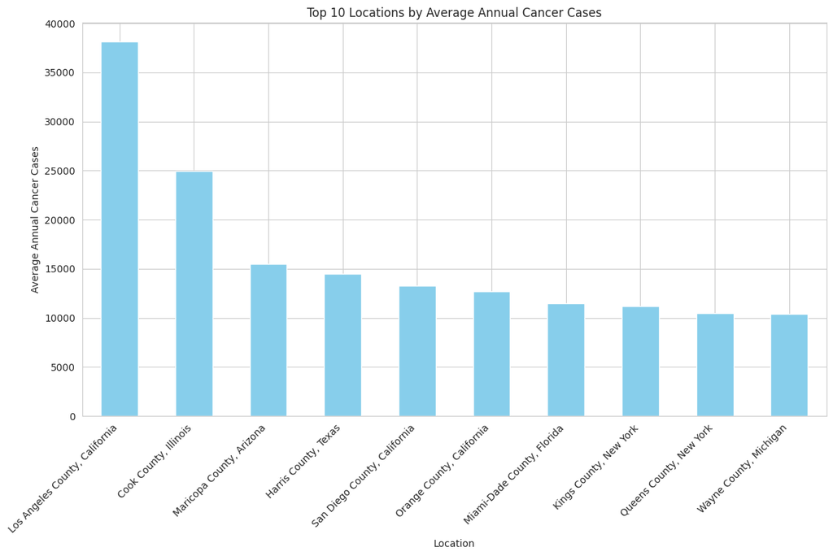

```python
top_avg_cases = merged_data.groupby('location')['avgcasecount'].mean().sort_values(ascending = False).head(10)
top_avg_cases.plot(kind = 'bar', figsize = (12, 8), color = 'skyblue')
plt.title('Top 10 Locations by Average Annual Cancer Cases')
plt.xlabel('Location')
plt.ylabel('Average Annual Cancer Cases')
plt.xticks(rotation = 45, ha = 'right') #Rotating x-axis labels to avoid overlap
plt.tight_layout() #Adjust layout to make room for the rotated x-axis labels
plt.show()
```

The code above groups the data using the **location** column, which contains both county and state information. It then calculates the mean of the **avgcasecount** for each location and sorts it in descending order to find the top 10 locations with the highest average case count (**avgcasecount**) and plots the data in the form of a bar chart. From the results above, Los Angeles County in California has the highest average number of cancer cases diagnosed annually.

#### **Research Question 2**: To what extent is the number of clinical trials per capita conducted within these regions associated with the majority type of health insurance covering the population?

The first step needed is to determine the majority type of health insurance in each region (public vs. private). This can be done by comparing the percentage of private coverage (**pctprivcoverage**) and the percentage of public coverage (**pctpubliccoverage**) of each region.

```python
merged_data['majority_insurance_type'] = np.where(merged_data['pctprivcoverage'] > merged_data['pctpubliccoverage'], 'Private', 'Public')
```

Now, the analysis of majority insurance type and clinical trials per capita (**clintrialspercap**) is possible. The first step is to compare the average clinical trials (**clintrialspercap**) between regions with a majority of private vs. public insurance type. The code below will first find the mean for number of clinical trials for each insurance type.

```python
insurance_clinical_trials = merged_data.groupby('majority_insurance_type')['clintrialspercap'].mean()
insurance_clinical_trials
```

```
majority_insurance_type
Private    160.061859
Public      75.999932
Name: clintrialspercap, dtype: float64
```

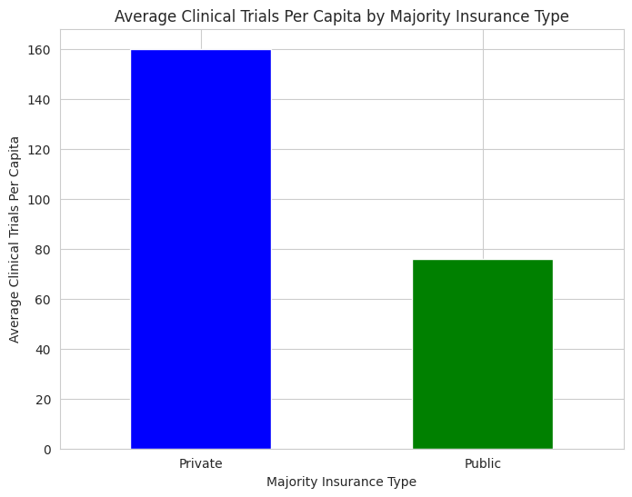

```python
#Plotting data onto a bar chart
insurance_clinical_trials.plot(kind = 'bar', figsize = (8, 6), color = ['blue', 'green'])
plt.title('Average Clinical Trials Per Capita by Majority Insurance Type')
plt.xlabel('Majority Insurance Type')
plt.ylabel('Average Clinical Trials Per Capita')
plt.xticks(rotation = 0) #Displays labels horizontally for better visuals
plt.show()
```

From the results above, there are a higher number of clinical trials per capita (**clintrialspercap**) conducted in areas where private insurance is the majority insurance type. Numerically, there are more than twice the amount of clinical trials where the majority insurance type is private compared to when the majority insurance type is public. We can infer that this observation could be due to factors such as access to clinical trials, and potentially willingness to participate in those clinical trials. Some of these potential factors will be explored later on in the form of a research question.

#### **Research Question 3**: What are the regions with the highest average number of deaths due to cancer?

Similar to **Research Question 1**, the first step is to calculate the average number of deaths (**avgdeathsperyear**) due to cancer sorted by regions. Then we can sort these regions in descending order to find the top 20 regions with the highest average number of deaths due to cancer.

```python
top_deaths = merged_data.groupby('location')['avgdeathsperyear'].mean().sort_values(ascending = False).head(20)
top_deaths
```

```
location
Los Angeles County, California       14010.0
Cook County, Illinois                 9445.0
Maricopa County, Arizona              5780.0
Harris County, Texas                  5108.0
San Diego County, California          4895.0
Orange County, California             4410.0
Miami-Dade County, Florida            4052.0
Wayne County, Michigan                3927.0
Kings County, New York                3824.0
Queens County, New York               3405.0
Broward County, Florida               3397.0
Riverside County, California          3377.0
Philadelphia County, Pennsylvania     3303.0
Palm Beach County, Florida            3265.0
Clark County, Nevada                  3120.0
Allegheny County, Pennsylvania        3100.0
Cuyahoga County, Ohio                 3091.0
King County, Washington               2939.0
Suffolk County, New York              2817.0
San Bernardino County, California     2778.0
Name: avgdeathsperyear, dtype: float64
```

```python
#Converting the series to a pandas dataframe for plotting
top_deaths = pd.DataFrame(top_deaths)
top_deaths.head()
```

| location | avgdeathsperyear |
| --- | --- |
| Los Angeles County, California | 14010.0 |
| Cook County, Illinois | 9445.0 |
| Maricopa County, Arizona | 5780.0 |
| Harris County, Texas | 5108.0 |
| San Diego County, California | 4895.0 |

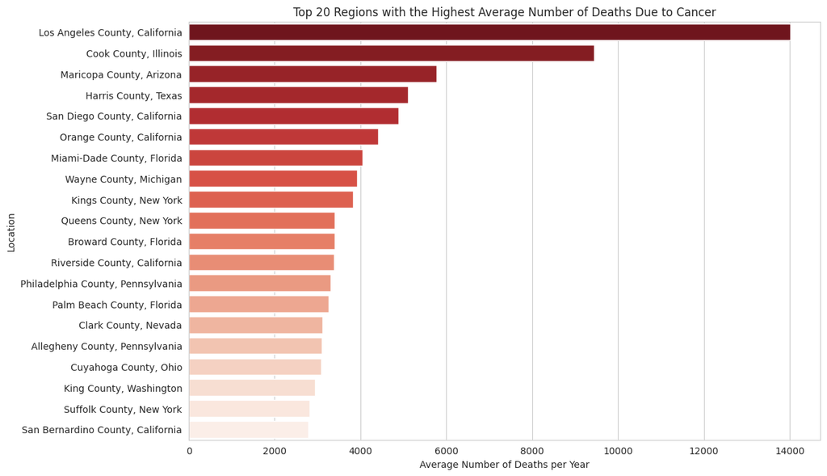

```python
#Plotting the top 20 regions with the highest average number of deaths due to cancer
plt.figure(figsize = (12, 8))
sns.barplot(x = 'avgdeathsperyear', y = 'location', hue = 'location', data = top_deaths, palette = 'Reds_r', dodge = False)
plt.title('Top 20 Regions with the Highest Average Number of Deaths Due to Cancer')
plt.xlabel('Average Number of Deaths per Year')
plt.ylabel('Location')
plt.legend([], [], frameon = False)
plt.show()
```

From the results above, we can easily identify the average number of deaths per year for the top 20 regions in descending order. The top 5 regions with the highest average number of deaths per year are:

> 1. **Los Angeles County, California**
> 2. **Cook County, Illinois**
> 3. **Maricopa County, Arizona**
> 4. **Harris County, Texas**
> 5. **San Diego County, California**

We can infer that regional characteristics such as population, economic status, and medical care may be reasons for such high average death numbers. Additionally, better access to healthcare and improved cancer resources and awareness could be needed in these top 5 regions.

#### **Research Question 4**: What is the average median income and median age in these top 20 regions?

Building off of **Research Question 3**, we can further specify our data by focusing on those top 20 regions. To do that, a list containing the top 20 regions (**location**) is made to filter through our "merged_data" dataframe and create a new dataframe with just those top 20 regions and its corresponding values.

```python
deaths_location = merged_data.groupby('location')['avgdeathsperyear'].mean().reset_index()
sorted_deaths = deaths_location.sort_values(by = 'avgdeathsperyear', ascending = False)
sorted_deaths = sorted_deaths.head(20)
top_locations = sorted_deaths['location'].tolist()
top_locations
```

```
['Los Angeles County, California',
 'Cook County, Illinois',
 'Maricopa County, Arizona',
 'Harris County, Texas',
 'San Diego County, California',
 'Orange County, California',
 'Miami-Dade County, Florida',
 'Wayne County, Michigan',
 'Kings County, New York',
 'Queens County, New York',
 'Broward County, Florida',
 'Riverside County, California',
 'Philadelphia County, Pennsylvania',
 'Palm Beach County, Florida',
 'Clark County, Nevada',
 'Allegheny County, Pennsylvania',
 'Cuyahoga County, Ohio',
 'King County, Washington',
 'Suffolk County, New York',
 'San Bernardino County, California']
```

```python
top_regions_data = merged_data[merged_data['location'].isin(top_locations)]
top_regions_data
```

|  | avgcasecount | avgdeathsperyear | target_deathrate | incidencerate | medianincome | popest2015 | povertypercent | clintrialspercap | binnedinc | medianage | ... | pctwhite | pctblack | pctasian | pctotherrace | pctmarriedhouseholds | birthrate | statefips | countyfips | avghouseholdsize | majority_insurance_type |
| --- | --- | --- | --- | --- | --- | --- | --- | --- | --- | --- | --- | --- | --- | --- | --- | --- | --- | --- | --- | --- | --- |
| 112 | 1962.667684 | 3120 | 167.7 | 453.549422 | 51241 | 2114801 | 15.6 | 405.239075 | (51046.4, 54545.6] | 36.4 | ... | 63.750484 | 10.836856 | 9.169757 | 10.145895 | 43.813065 | 5.125073 | 32 | 3 | 2.78 | Private |
| 299 | 8999.000000 | 2939 | 152.7 | 464.200000 | 75738 | 2117125 | 11.3 | 620.653008 | (61494.5, 125635] | 37.2 | ... | 68.068382 | 6.198491 | 15.576735 | 2.803169 | 46.850306 | 5.202119 | 53 | 33 | 2.45 | Private |
| 365 | 10411.000000 | 3927 | 197.9 | 528.700000 | 41434 | 1759335 | 24.1 | 470.063973 | (40362.7, 42724.4] | 37.8 | ... | 53.342526 | 39.414346 | 2.904772 | 1.728810 | 37.156645 | 5.676241 | 26 | 163 | 2.63 | Private |
| 386 | 11217.000000 | 3824 | 153.8 | 452.300000 | 47547 | 2636735 | 23.4 | 42.476775 | (45201, 48021.6] | 34.4 | ... | 43.391084 | 33.540583 | 11.478238 | 8.873103 | 37.530399 | 5.227447 | 36 | 47 | 2.74 | Private |
| 999 | 38150.000000 | 14010 | 148.4 | 405.500000 | 55686 | 10170292 | 18.7 | 255.941521 | (54545.6, 61494.5] | 35.6 | ... | 53.258710 | 8.276140 | 14.129380 | 19.591522 | 44.581650 | 4.705281 | 6 | 37 | 3.02 | Private |
| 1012 | 12694.000000 | 4410 | 143.8 | 418.600000 | 76061 | 3169776 | 12.9 | 145.751624 | (61494.5, 125635] | 37.1 | ... | 63.220680 | 1.662864 | 18.945088 | 11.816812 | 54.606268 | 4.827808 | 6 | 59 | 3.04 | Private |
| 1015 | 8857.000000 | 3377 | 154.6 | 414.500000 | 56877 | 2361026 | 17.1 | 57.178532 | (54545.6, 61494.5] | 34.5 | ... | 64.610414 | 6.265187 | 6.185118 | 17.456328 | 53.803745 | 5.475268 | 6 | 65 | 3.24 | Private |
| 1018 | 7241.000000 | 2778 | 168.0 | 423.100000 | 51951 | 2128133 | 20.4 | 62.026199 | (51046.4, 54545.6] | 32.5 | ... | 62.154061 | 8.549248 | 6.678254 | 17.038728 | 51.294510 | 6.007621 | 6 | 71 | 3.33 | Private |
| 1020 | 13294.000000 | 4895 | 157.1 | 434.900000 | 66034 | 3299521 | 14.7 | 139.111101 | (61494.5, 125635] | 35.1 | ... | 70.851690 | 5.065812 | 11.450233 | 6.707309 | 49.617834 | 4.953959 | 6 | 73 | 2.86 | Private |
| 1427 | 8954.000000 | 3397 | 157.6 | 438.300000 | 51485 | 1896425 | 14.5 | 216.723572 | (51046.4, 54545.6] | 40.0 | ... | 62.617462 | 27.837476 | 3.499006 | 2.985809 | 43.042949 | 4.663811 | 12 | 11 | 2.73 | Private |
| 1467 | 11495.000000 | 4052 | 137.3 | 408.000000 | 42754 | 2693117 | 20.4 | 164.864727 | (42724.4, 45201] | 39.0 | ... | 75.750594 | 18.642295 | 1.586598 | 2.425501 | 43.271472 | 4.372228 | 12 | 86 | 3.08 | Private |
| 1475 | 8287.000000 | 3265 | 144.3 | 422.300000 | 52225 | 1422789 | 14.9 | 151.111655 | (51046.4, 54545.6] | 44.1 | ... | 74.987997 | 17.972434 | 2.503906 | 2.180945 | 45.443271 | 5.134425 | 12 | 99 | 2.54 | Private |
| 1613 | 7637.000000 | 3091 | 187.1 | 485.000000 | 44138 | 1255921 | 19.6 | 555.767441 | (42724.4, 45201] | 40.4 | ... | 63.607742 | 29.688194 | 2.775277 | 1.207262 | 36.951932 | 4.879604 | 39 | 35 | 2.31 | Private |
| 1697 | 7913.000000 | 3100 | 182.1 | 501.200000 | 52385 | 1230459 | 13.1 | 624.157327 | (51046.4, 54545.6] | 40.9 | ... | 80.812008 | 13.006673 | 3.274756 | 0.404989 | 42.458652 | 5.044224 | 42 | 3 | 2.26 | Private |
| 1746 | 8236.000000 | 3303 | 211.7 | 533.500000 | 39037 | 1567442 | 25.8 | 742.611210 | (37413.8, 40362.7] | 33.7 | ... | 41.672154 | 42.757570 | 6.864827 | 5.573247 | 27.459943 | 5.282606 | 42 | 101 | 2.59 | Private |
| 1860 | 14477.000000 | 5108 | 161.4 | 433.800000 | 54230 | 4538028 | 17.3 | 391.359419 | (51046.4, 54545.6] | 32.8 | ... | 63.121729 | 18.861747 | 6.572709 | 8.734237 | 46.913495 | 6.028644 | 48 | 201 | 2.88 | Private |
| 2086 | 10502.000000 | 3405 | 138.8 | 435.200000 | 56866 | 2339150 | 15.4 | 16.672723 | (54545.6, 61494.5] | 37.7 | ... | 41.146319 | 18.479110 | 24.384794 | 12.151808 | 44.720000 | 4.844911 | 36 | 81 | 2.91 | Private |
| 2097 | 8895.000000 | 2817 | 163.8 | 528.000000 | 85886 | 1501587 | 7.7 | 181.807648 | (61494.5, 125635] | 40.6 | ... | 80.948638 | 7.662320 | 3.781605 | 4.950535 | 57.618624 | 4.419519 | 36 | 103 | 2.98 | Private |
| 2373 | 24965.000000 | 9445 | 177.0 | 470.800000 | 55058 | 5238216 | 17.1 | 371.118717 | (54545.6, 61494.5] | 35.9 | ... | 56.842582 | 23.982596 | 6.772830 | 9.847733 | 41.008791 | 4.994881 | 17 | 31 | 2.65 | Private |
| 2741 | 15470.000000 | 5780 | 146.6 | 401.400000 | 53929 | 4167947 | 17.1 | 177.545444 | (51046.4, 54545.6] | 35.6 | ... | 79.580767 | 5.221044 | 3.789014 | 6.188306 | 47.036501 | 5.392191 | 4 | 13 | 2.75 | Private |

20 rows × 37 columns

From the results above, the average metrics associated with median income and median age can be calculated. The usage of a scatter plot would be the most effective way to visualize the association between average median income and median age in these regions. Each plot on the scatter plot will represent a region.

```python
average_metrics = top_regions_data.groupby('location').agg({
                                                            'medianincome': 'mean',
                                                            'medianage': 'mean'
                                                            }).reset_index()
```

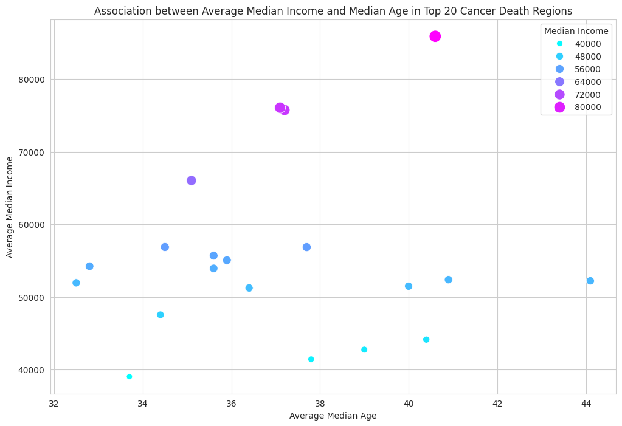

```python
plt.figure(figsize = (12, 8))
sns.scatterplot(x = 'medianage', y = 'medianincome', data = average_metrics, size = 'medianincome', hue = 'medianincome', palette = 'cool', sizes = (50, 200))
plt.title('Association between Average Median Income and Median Age in Top 20 Cancer Death Regions')
plt.xlabel('Average Median Age')
plt.ylabel('Average Median Income')
plt.legend(title = 'Median Income')
plt.grid(True)
plt.show()
```

#### **Research Question 5**: Is there a pattern associated with poverty percentage and the incident rate?

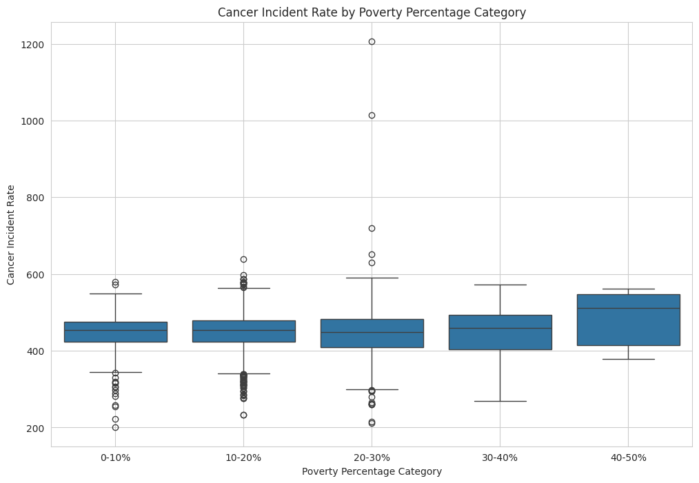

```python
#Categorizing poverty percentage into bins
merged_data['poverty_category'] = pd.cut(merged_data['povertypercent'], bins = [0, 10, 20, 30, 40, 50], labels = ['0-10%', '10-20%', '20-30%', '30-40%', '40-50%'])

plt.figure(figsize = (12, 8))
sns.boxplot(x = 'poverty_category', y = 'incidencerate', data = merged_data)
plt.title('Cancer Incident Rate by Poverty Percentage Category')
plt.xlabel('Poverty Percentage Category')
plt.ylabel('Cancer Incident Rate')
plt.grid(True)
plt.show()
```

From the results above, we can observe several insights about our data.

1. **Median Incident Rate**:

   > The median cancer incident rate, indicated by the horizontal line inside each box, remains fairly consistent between the poverty categories. The only significant change is the jump from 30-40% to 40-50%.
2. **Interquartile Range (IQR)**:

   > The IQR, represented by the middle 50% of the boxplots, or the height of the boxes, varies accross all categories. There is a similar range between the 0-10% and 10-20% categories, but the general trend observed is that the IQR gets larger as the category values increase.
3. **Outliers**:

   > There are numerous outliers in the 0-10%, 10-20%, and 20-30% categories. These outliers are represented as the dots that completely fall out of the boxplot range beyond the whiskers. These outliers could indicate that there are other factors besides poverty that could influence the cancer incident rates.
4. **Range of Data**:

   > The range of the data is represented by the extended whiskers of each boxplot. The 20-30% and 30-40% categories have the largest range of cancer indicent rates.
5. **Comparisons Across Categories**:

   > The 40-50% category has a higher median but smaller range than all of the other categories. This could possibly suggest that higher poverty rates could be associated with higher cancer incident rates.

#### **Research Question 6**: To what extent is the average number of deaths within these regions associated with the average median income and poverty percentage within these regions?

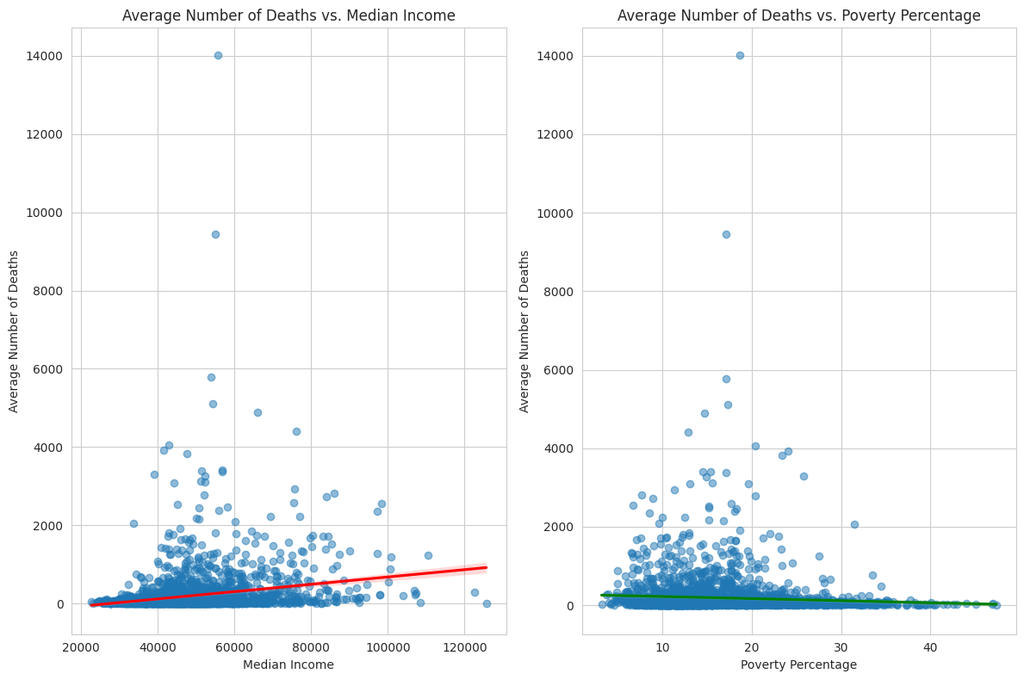

```python
#Scatter plot for average number of deaths and average median income
plt.figure(figsize = (12, 8))
plt.subplot(1, 2, 1) #1 row, 2 columns, 1st subplot
sns.regplot(x = 'medianincome', y = 'avgdeathsperyear', data = merged_data, scatter_kws = {'alpha': 0.5}, line_kws = {'color': 'red'})
plt.title('Average Number of Deaths vs. Median Income')
plt.xlabel('Median Income')
plt.ylabel('Average Number of Deaths')


#Scatter plot for average number of deaths and poverty percentage
plt.subplot(1, 2, 2,) #1 row, 2 columns, 2nd subplot
sns.regplot(x = 'povertypercent', y = 'avgdeathsperyear', data = merged_data, scatter_kws = {'alpha': 0.5}, line_kws = {'color': 'green'})
plt.title('Average Number of Deaths vs. Poverty Percentage')
plt.xlabel('Poverty Percentage')
plt.ylabel('Average Number of Deaths')
plt.tight_layout()
plt.show()
```

The **Pearsons Correlation Coefficient**, or r, is a statistical measurement of the strength and direction of the linear correlation between two sets of data.

```python
income_correlation = merged_data[['avgdeathsperyear', 'medianincome']].corr().iloc[0,1]
poverty_correlation = merged_data[['avgdeathsperyear', 'povertypercent']].corr().iloc[0,1]

print('Correlation between average number of deaths and median income:', income_correlation)
print('Correlation between average number of deaths and poverty percentage:', poverty_correlation)
```

```
Correlation between average number of deaths and median income: 0.22320675719703434
Correlation between average number of deaths and poverty percentage: -0.06691793872052998
```

Using the calculated correlation coefficient, we can now analyze the relationships between the average number of deaths and the median income and poverty percentage.

**Summary of Results**: The weak correlation coefficients of both variables suggests that neither median income or poverty percentage strongly determines the average number of deaths in a region. While they both do have a small correlation, the results indicate that there are other potential factors such as healthcare that can impact the average number of deaths in a region.

#### **Research Question 7**: Is there a pattern associated with incident rate and the average number of deaths with the percentage of minorities?

Similar to what was done for **Research Question 6**, calculating a correlation coefficient is the best way to tell whether or not there is an association between incident rate and percentage of minorities as well as the average number of deaths and minorities. What is being tested here is whether or not a population percentage of a race has an association to both cancer incidence rate and the average number of deaths due to cancer. The best way to visualize this is through the use of a scatter plot with a regression line. The minority groups tested include percent Black (**pctblack**), percent Asian (**pctasian**), and percent other races (**pctotherrace**). percent White (**pctwhite**) was left out of this test as it is not apart of the minority population and will be tested individually as a later research question.

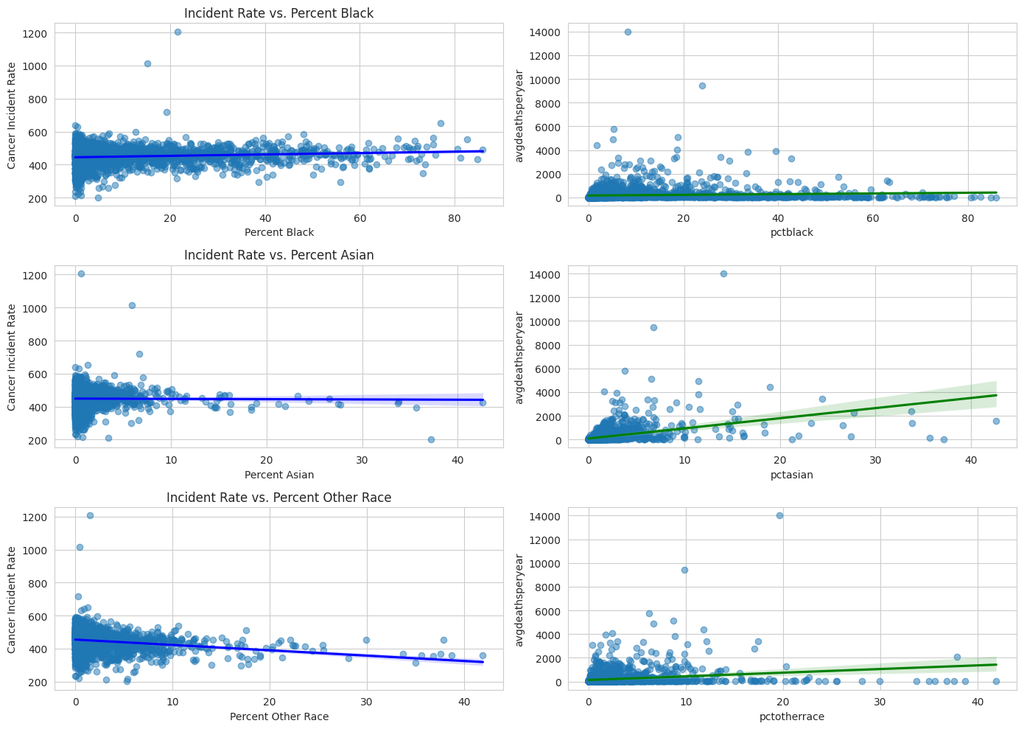

```python
#Creating readable names for the minority groups
minority_groups = ['pctblack', 'pctasian', 'pctotherrace']
renamed_groups = ['Percent Black', 'Percent Asian', 'Percent Other Race']
fig, axs = plt.subplots(3, 2, figsize = (14, 10))

#Creating the scatter plots
for i, minority in enumerate(minority_groups):
  #Plots for incident rate
  sns.regplot(x = minority, y = 'incidencerate', data = merged_data, ax = axs[i, 0], scatter_kws = {'alpha': 0.5}, line_kws = {'color': 'blue'})
  axs[i, 0].set_title(f'Incident Rate vs. {renamed_groups[i]}')
  axs[i, 0].set_xlabel(renamed_groups[i])
  axs[i, 0].set_ylabel('Cancer Incident Rate')

  #Plots for average number of deaths
  sns.regplot(x = minority, y = 'avgdeathsperyear', data = merged_data, ax = axs[i, 1], scatter_kws = {'alpha': 0.5}, line_kws = {'color': 'green'})
  axs[i, 0].set_title(f'Incident Rate vs. {renamed_groups[i]}')
  axs[i, 0].set_xlabel(renamed_groups[i])
  axs[i, 0].set_ylabel('Cancer Incident Rate')

plt.tight_layout()
plt.show()
```

```python
#Finding the correlation coefficients
for minority in minority_groups:
  incidence_correlation = merged_data[[minority, 'incidencerate']].corr().iloc[0, 1]
  deaths_correlation = merged_data[[minority, 'avgdeathsperyear']].corr().iloc[0, 1]
  print(f'Correlation between {minority} and Cancer Incident Rate: {incidence_correlation}')
  print(f'Correlation between {minority} and Average Number of Deaths: {deaths_correlation}')
```

```
Correlation between pctblack and Cancer Incident Rate: 0.11348895935895496
Correlation between pctblack and Average Number of Deaths: 0.08460710216917364
Correlation between pctasian and Cancer Incident Rate: -0.008123427032149001
Correlation between pctasian and Average Number of Deaths: 0.4430742259184566
Correlation between pctotherrace and Cancer Incident Rate: -0.20874833601098114
Correlation between pctotherrace and Average Number of Deaths: 0.215149358689697
```

From the results above, we can now analyze the data and determine if there is any association between the percentage of minority groups and both incidence rate and average number of deaths.

**Percent Black Population**

> **Incident Rate Correlation**: 0.113  
> There is a weak positive correlation between the percentage of black population and cancer incident rates. As the black population percentage increases, there is a slight increase in the cancer incident rates.  
> **Average Number of Deaths Correlation**: 0.085  
> There is a weak positive correlation between the percentage of black population and the average number of deaths. As the black population percentage increases, there is a slight increase in the average number of deaths.  
> **Final Observations**: Given the weak correlations, we can determine that other factors may play a more significant role than the percent black population (**pctblack**) on the incident rates and average number of deaths.

**Percent Asian Population**

> **Incident Rate Correlation**: -0.008  
> There is nearly no correlation between the percentage of asian population and cancer incident rates. Such a small correlation coefficient indicates no significant relationship.  
> **Average Number of Deaths Correlation**: 0.443  
> There is a moderate positive correlation between the percentage of asian population and the average number of deaths. As the asian population percentage increases, there is a moderate increase in the average number of deaths. This correlation suggests that areas with a higher asian population percentage might experience higher cancer mortality.  
> **Final Observations**: The differnce between correlations of incident rate and average number of deaths when associated to the percent asian population is interesting. The average number of deaths shares a moderate positive correlation with the percent asian population while the incident rate of cancer shares close to zero correlation with the percent asian population (**pctasian**).

**Percent Other Race Population**

#### **Research Question 8**: What is the correlation between the percentage of white population and the cancer incident rates as well as the average number of deaths?

As a follow up to **Research Question 7**, this research question now looks to see if there is an association with the percentage of white population and the cancer incident rates and average number of deaths. As in the previous question, the best way to determine if such an association exists is by finding the correlation coefficient and displaying the data on a scatter plot with a regression line.

```python
#Calculate the number of white individuals per entry
merged_data['white_population'] = merged_data['pctwhite'] / 100 * merged_data['popest2015']
#Group by region and sum up the white population
white_population_per_region = merged_data.groupby('location')['white_population'].mean()
white_population_per_region
```

```
location
Abbeville County, South Carolina      17424.572550
Acadia Parish, Louisiana              49418.948315
Accomack County, Virginia             22424.427992
Ada County, Idaho                    396879.343669
Adair County, Iowa                     7117.039591
                                         ...
Yukon-Koyukuk Census Area, Alaska      1286.197024
Yuma County, Arizona                 157580.581143
Yuma County, Colorado                  9552.282180
Zapata County, Texas                  13969.141041
Zavala County, Texas                  11153.531509
Name: white_population, Length: 3047, dtype: float64
```

[figure not shown]

```python
#Setting up the figure and axes
fig, axs = plt.subplots(1, 2, figsize = (12, 6)) #1 row, 2 columns

#Plot for incident rate
sns.regplot(x = 'pctwhite', y = 'incidencerate', data = merged_data, ax = axs[0], scatter_kws = {'alpha': 0.5}, line_kws = {'color': 'blue'})
axs[0].set_title('Incident Rate vs. Percent White')
axs[0].set_xlabel('Percentage of White Population')
axs[0].set_ylabel('Cancer Incident Rate')

#Plot for average number of deaths
sns.regplot(x = 'pctwhite', y = 'avgdeathsperyear', data = merged_data, ax = axs[1], scatter_kws = {'alpha': 0.5}, line_kws = {'color': 'green'})
axs[0].set_title('Average Number of Deaths vs. Percent White')
axs[0].set_xlabel('Percentage of White Population')
axs[0].set_ylabel('Average Number of Deaths')

plt.tight_layout()
plt.show()
```

```python
#Finding correlation coefficients
incidence_correlation = merged_data[['pctwhite', 'incidencerate']].corr().iloc[0, 1]
deaths_correlation = merged_data[['pctwhite', 'avgdeathsperyear']].corr().iloc[0, 1]
print(f'Correlation between pctwhite and Cancer Incident Rate: {incidence_correlation}')
print(f'Correlation between pctwhite and Average Number of Deaths: {deaths_correlation}')
```

```
Correlation between pctwhite and Cancer Incident Rate: -0.014509829490172895
Correlation between pctwhite and Average Number of Deaths: -0.18715902284470992
```

From the results above, we can now analyze the data and determine if there is any association between the percentage of white population and both the cancer incident rate and the average number of deaths. **Percent White Population**

> **Incident Rate Correlation**: -0.015  
> There is a very weak negative correlation between the percentage of white population and cancer incident rates. Such a weak correlation coefficient suggests that there is essentially no significant relationship between the percentage of white population and cancer incident rates.  
> **Average Number of Deaths Correlation**: -0.187  
> There is a weak negative correlation between the percentage of white population and average number of deaths. As the percentage of white population increases, there is a slight decrease in the average number of deaths. However, the weak correlation suggests that there are other factors that have a more significant influence on the average number of deaths.

After looking at the correlations between the population percentage of a race and cancer incident rates and average number of deaths, the possibility of an association between race and the average number of deaths due to cancer is the question we have chosen to model our null hypothesis under.

## *Part 3: Constructing a Hypothesis Test*

After conducting our research questions, we were further interested in seeing if the percentage of race of any given region had an association to the average number of deaths. Our first step in beginning the hypothesis test is to construct a null hypothesis.

### *Section 5: Constructing a Null Hypothesis*

**Null Hypothesis (H₀)**: There is no association between the percentage of any given race and the average number of deaths per year.  
**Alternative Hypothesis (Hₐ)**: There is an association between the percentage of any given race and the average number of deaths per year.

The following tables have been constucted to store the relevant statistics needed for the hypothesis test.

> **Independent Variables**: pctwhite, pctblack, pctasian, pctotherrace

> > By using the percentage of white indivuduals, we will be able to gauge whether higher percentages of minorities ultimately correlate to more deaths.

> **Dependent Variable**: avgdeathsperyear

> > This is our statistic that we are using to gauge if there is any sort of discrimination.

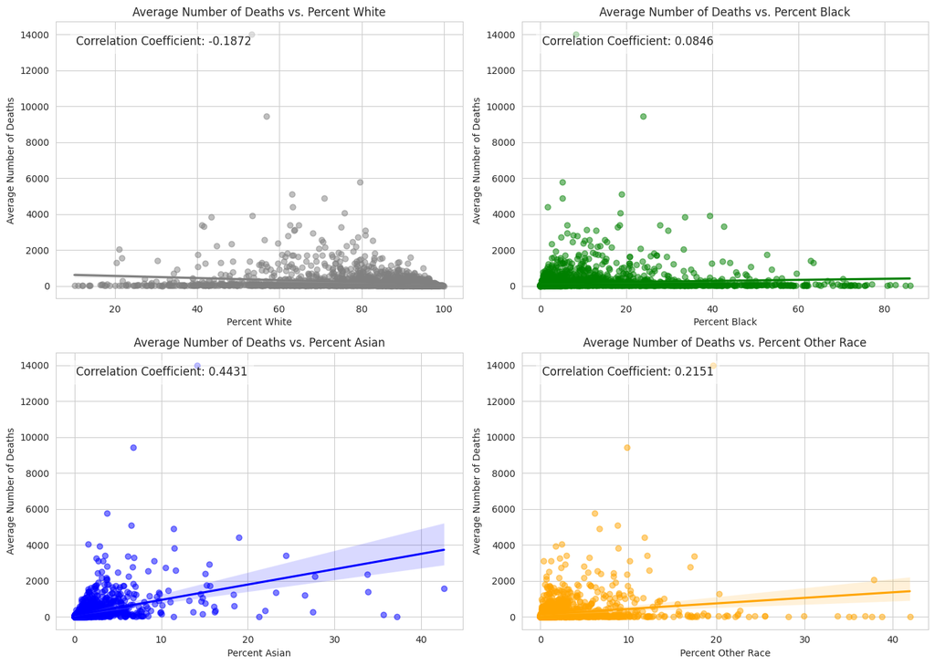

```python
#Define readable names for the groups
all_groups = ['pctwhite', 'pctblack', 'pctasian', 'pctotherrace']
renamed_groups = ['Percent White', 'Percent Black', 'Percent Asian', 'Percent Other Race']
colors = ['grey', 'green', 'blue', 'orange']
original_correlations = []

for group in all_groups:
  correlation = merged_data[[group, 'avgdeathsperyear']].corr().iloc[0, 1]
  original_correlations.append(correlation)

#Creating a 2x2 grid of subplots
fig, axs = plt.subplots(2, 2, figsize = (14, 10))
axs = axs.flatten() #Simplify Indexing

for i, group in enumerate(all_groups):
  #Plot for average number of deaths
  sns.regplot(x = group, y = 'avgdeathsperyear', data = merged_data, ax = axs[i], scatter_kws = {'alpha': 0.5, 'color': colors[i]}, line_kws = {'color': colors[i]})
  axs[i].set_title(f'Average Number of Deaths vs. {renamed_groups[i]}')
  axs[i].set_xlabel(renamed_groups[i])
  axs[i].set_ylabel('Average Number of Deaths')

  #Annotate the plot with the correlation coefficient
  axs[i].text(0.05, 0.95, f'Correlation Coefficient: {original_correlations[i]:.4f}', transform = axs[i].transAxes,
              fontsize = 12, verticalalignment = 'top', bbox = dict(boxstyle = 'round, pad = 0.5', facecolor = 'white', alpha = 0.5)
              )

plt.tight_layout()
plt.show()
```

#### **Testing Process**

1. **Initial Thoughts**

   > From the results above, we can see that there are non-zero correlations between all four races, with an inverse relationship for more white dense populations. However, we still cannot infer this correlation without further analysis. We fill further analyze this by conducting a randomization test for these four variables to determine if the correlation is an actual correlation of just one of chance.
2. **Choosing a Sample Size**

   > As the sample size is small, the whole sample size will be used as most calculations can be done with the use of computational resources. As this dataset is public and no longer being updated, the worry of integrity and overfitting is not necessary.
3. **Final Data Cleaning for the Randomization Test**

   > The data was cleaned once more to only include data relevant to the hypothesis tesing.
4. **Carrying Out the Test**

   > Creating four histograms (one for each racial group) based on the randomization test to better visualize and analyze the data to decide whether or not to accept or reject the null hypothesis.

```python
#Cleaning the data one final time
shuffled_labels = pd.DataFrame({
    'avgdeathsperyear': merged_data['avgdeathsperyear'],
    'pctwhite': merged_data['pctwhite'],
    'pctblack': merged_data['pctblack'],
    'pctasian': merged_data['pctasian'],
    'pctotherrace': merged_data['pctotherrace']
                              })
shuffled_labels.head()
```

|  | avgdeathsperyear | pctwhite | pctblack | pctasian | pctotherrace |
| --- | --- | --- | --- | --- | --- |
| 0 | 469 | 81.780529 | 2.594728 | 4.821857 | 1.843479 |
| 1 | 70 | 89.228509 | 0.969102 | 2.246233 | 3.741352 |
| 2 | 50 | 90.922190 | 0.739673 | 0.465898 | 2.747358 |
| 3 | 202 | 91.744686 | 0.782626 | 1.161359 | 1.362643 |
| 4 | 26 | 94.104024 | 0.270192 | 0.665830 | 0.492135 |

```python
#Running of A/B Testing
randomized_correlations_matrix = {group: [] for group in all_groups}
randomized_correlations_matrix

for group in shuffled_labels:
  repetitions = 10000
  for i in range(repetitions):
    for group in all_groups:
      shuffled_labels[group] = shuffled_labels[group].sample(frac = 1).reset_index(drop = True)
      randomized_correlations_matrix[group].append(shuffled_labels[[group, 'avgdeathsperyear']].corr().iloc[0, 1])
```

```python
#Converting the dictionary into a pandas dataframe
all_randomized_correlations = pd.DataFrame(randomized_correlations_matrix)
all_randomized_correlations.head()
```

|  | pctwhite | pctblack | pctasian | pctotherrace |
| --- | --- | --- | --- | --- |
| 0 | -0.020734 | -0.022850 | -0.002661 | -0.000757 |
| 1 | -0.003216 | 0.032323 | -0.007459 | -0.020247 |
| 2 | 0.024753 | -0.001666 | 0.026004 | 0.005094 |
| 3 | 0.014454 | 0.014601 | -0.012106 | -0.011528 |
| 4 | 0.023870 | -0.011189 | -0.007129 | -0.031600 |

Using the newly constructed table based on the correlation coefficients, we plot all four histograms and the p-values (original observed data). We then analyze where the p-value lies in correlation to the rest of the data on the histogram and decided whether or not to reject or accept the null hypothesis.

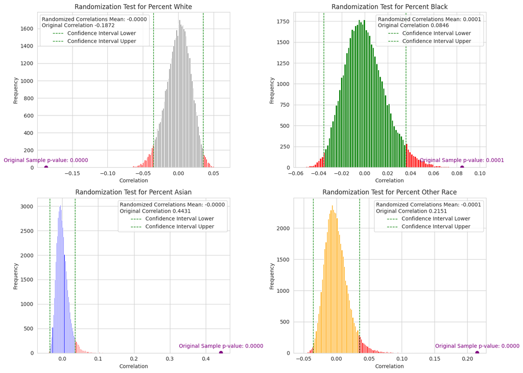

```python
fig, axs = plt.subplots(2, 2, figsize = (14, 10))
axs = axs.flatten()

for i in range(len(renamed_groups)):
  randomized_correlations = all_randomized_correlations.iloc[:, i]
  original_corr = original_correlations[i]
  p_value = (randomized_correlations >= abs(original_corr)).sum() / len(randomized_correlations)

  #Creation of Confidence Intervals
  z_score = 1.96
  mean = randomized_correlations.mean()
  std_dev = randomized_correlations.std()
  ci_lower = mean - z_score * std_dev
  ci_upper = mean + z_score * std_dev

  #Plot histograms
  n, bins, patches = axs[i].hist(randomized_correlations, bins = 100, color = colors[i], alpha = 1)

  #Changing the color of the bins outside of confidence interval to red
  for patch, leftside, rightside in zip(patches, bins[: -1], bins[1:]):
    if leftside < ci_lower or rightside > ci_upper:
      plt.setp(patch, 'facecolor', 'red')

  #Add purple point for observed data on x-axis
  axs[i].scatter(original_corr, 2, color = 'purple', s = 40, zorder = 5)
  label = f'Original Sample p-value: {p_value:.4f}'

  #Annotate with the p-value
  axs[i].annotate(label, (original_corr, 2), textcoords = 'offset points', xytext = (0, 10), ha = 'center', color = 'purple')

  #Add vertical lines for the ci bounds
  axs[i].axvline(ci_lower, color = 'green', linestyle = 'dashed', linewidth = 1, label='Confidence Interval Lower')
  axs[i].axvline(ci_upper, color = 'green', linestyle = 'dashed', linewidth = 1, label='Confidence Interval Upper')

  #Label Subplot
  axs[i].set_title(f'Randomization Test for {renamed_groups[i]}')
  axs[i].set_xlabel('Correlation')
  axs[i].set_ylabel('Frequency')

  #Legend for the Subplot
  axs[i].legend(title = f'Randomized Correlations Mean: {mean:.4f}\nOriginal Correlation {original_corr:.4f}')

plt.tight_layout()
plt.show()
```